# R-Code aus der Vorlesung

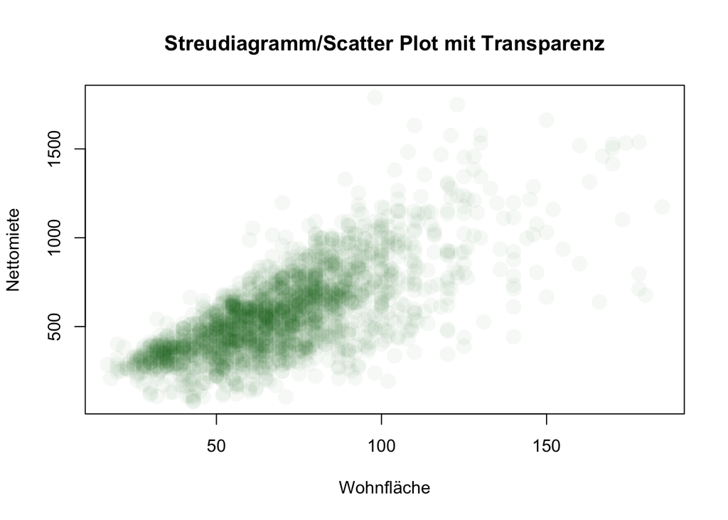

```r
# der vierte Wert in rgb(...) stellt die Stärke der Transparenz ein
plot(mietspiegel$wfl, mietspiegel$nm, xlab = "Wohnfläche",
     ylab = "Nettomiete", main = "Streudiagramm/Scatter Plot mit Transparenz",
     col=rgb(0,100,0,10,maxColorValue=255), pch=16, cex=2)
```

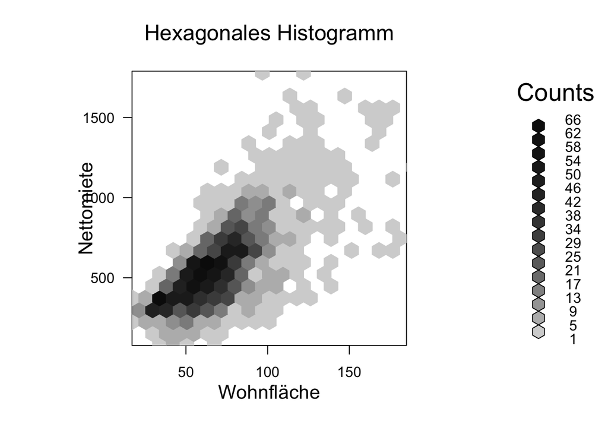

```r
library(hexbin)
bin<-hexbin(mietspiegel$wfl, mietspiegel$nm, xbins=20)
plot(bin, xlab = "Wohnfläche", ylab = "Nettomiete",
     main = "Hexagonales Histogramm")
```

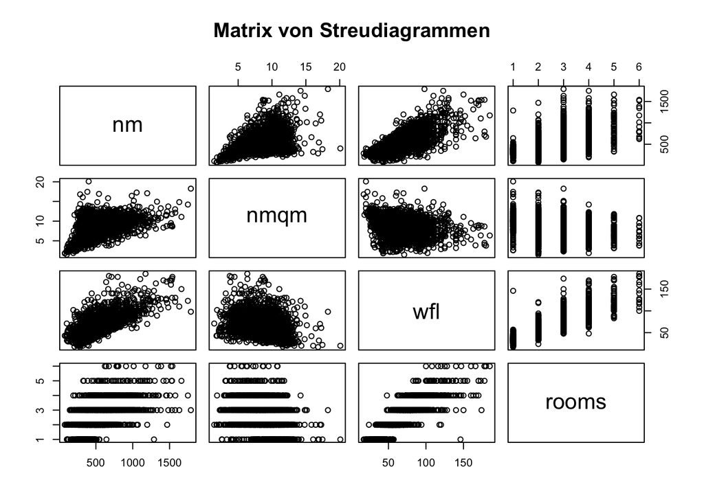

```r
pairs(~nm+nmqm+wfl+rooms,data=mietspiegel, main="Matrix von Streudiagrammen")
```

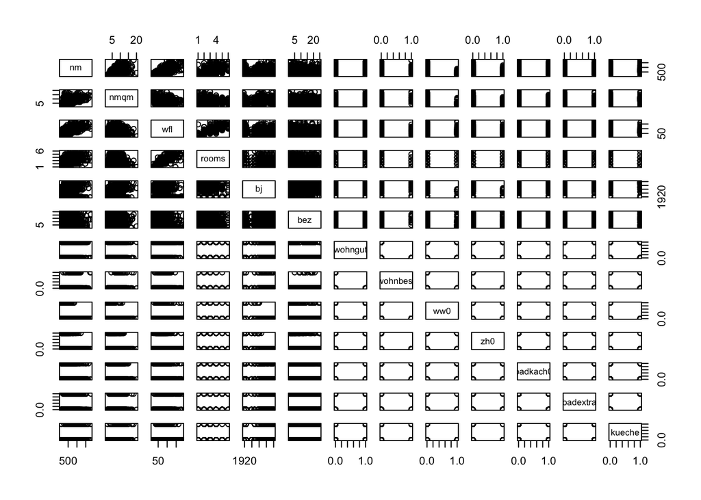

```r
pairs(mietspiegel)
```

### Lineare Regression

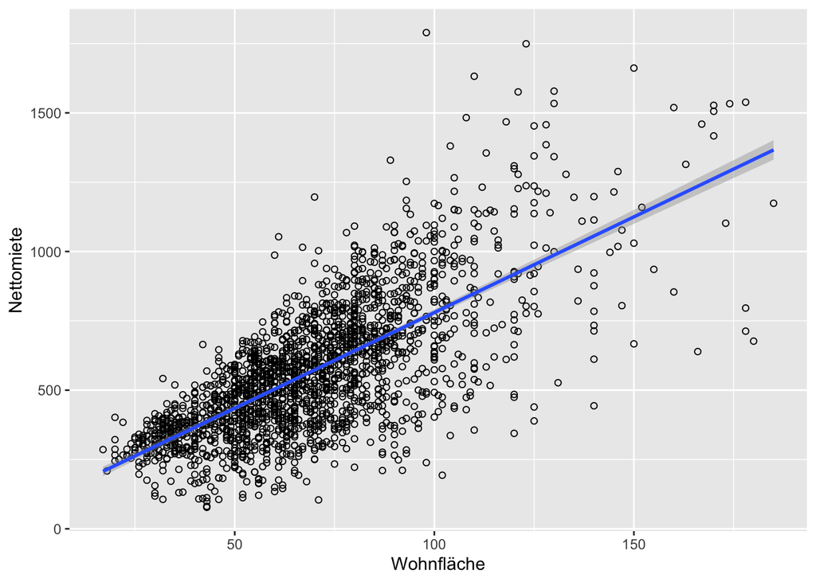

```r
ggplot(mietspiegel, aes(y=nm, x=wfl)) +
  geom_point(shape=1) +    # Use hollow circles
  geom_smooth(method=lm) + # Add linear regression line
  xlab("Wohnfläche") +
  ylab("Nettomiete")
```

Modell explizit berechnen:

```r
mieten_regression <- lm(nm ~ wfl, data = mietspiegel)
summary(mieten_regression)
```

```
##
## Call:
## lm(formula = nm ~ wfl, data = mietspiegel)
##
## Residuals:
##     Min      1Q  Median      3Q     Max
## -655.18  -97.41    7.40   98.73 1023.45
##
## Coefficients:
##             Estimate Std. Error t value             Pr(>|t|)
## (Intercept)  89.8469    11.2644   7.976  0.00000000000000249 ***
## wfl           6.9006     0.1522  45.334 < 0.0000000000000002 ***
## ---
## Signif. codes:  0 '***' 0.001 '**' 0.01 '*' 0.05 '.' 0.1 ' ' 1
##
## Residual standard error: 173.5 on 2051 degrees of freedom
## Multiple R-squared:  0.5005, Adjusted R-squared:  0.5003
## F-statistic:  2055 on 1 and 2051 DF,  p-value: < 0.00000000000000022
```

Lineare Regression mit Polynom höheren Grades:

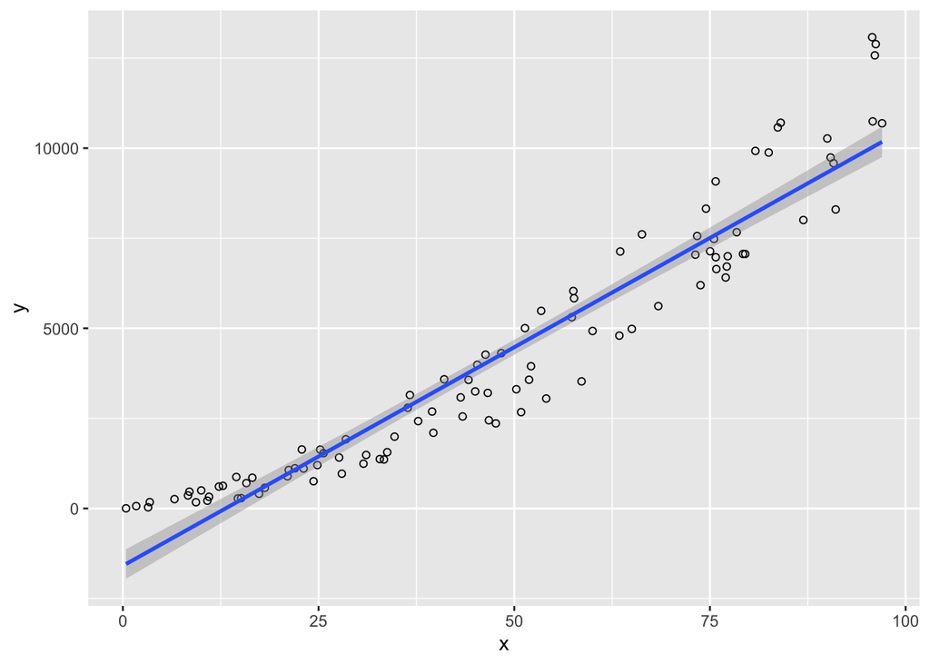

```r
# quadratische Beziehung
x <- runif(100, 0, 100)
e <- runif(100, 0, 50)
y <- x^2 + x * e

# Regressionsgerade
ggplot() + aes(y=y, x=x) +
  geom_point(shape=1) +    # Use hollow circles
  geom_smooth(method=lm) # Add linear regression line
```

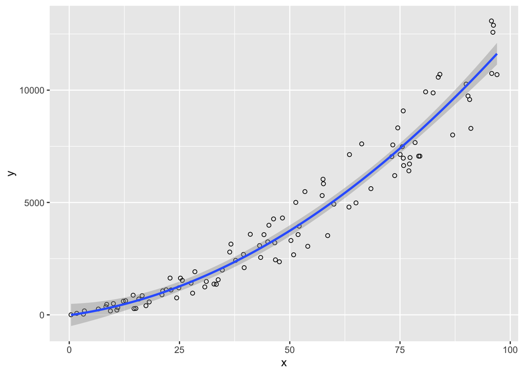

```r
# quadratische Beziehung
ggplot() + aes(y=y, x=x) +
  geom_point(shape=1) +    # Use hollow circles
  geom_smooth(method=lm, formula=y~poly(x,2)) # Add quadratic regression line
```

```r
# Beides mit lm() berechnen
lin_regression <- lm(y ~ x)
quad_regression <- lm(y ~ poly(x,2))
summary(lin_regression)
```

```
##
## Call:
## lm(formula = y ~ x)
##
## Residuals:
##      Min       1Q   Median       3Q      Max
## -1990.54  -842.65    -7.29   634.66  3058.04
##
## Coefficients:
##              Estimate Std. Error t value             Pr(>|t|)
## (Intercept) -1590.483    208.629  -7.624       0.000000000016 ***
## x             121.293      3.781  32.078 < 0.0000000000000002 ***
## ---
## Signif. codes:  0 '***' 0.001 '**' 0.01 '*' 0.05 '.' 0.1 ' ' 1
##
## Residual standard error: 1047 on 98 degrees of freedom
## Multiple R-squared:  0.913,  Adjusted R-squared:  0.9122
## F-statistic:  1029 on 1 and 98 DF,  p-value: < 0.00000000000000022
```

```r
summary(quad_regression)
```

```
##
## Call:
## lm(formula = y ~ poly(x, 2))
##
## Residuals:
##      Min       1Q   Median       3Q      Max
## -2097.31  -497.37   -51.13   390.24  1725.41
##
## Coefficients:
##             Estimate Std. Error t value             Pr(>|t|)
## (Intercept)   4198.9       81.2  51.712 < 0.0000000000000002 ***
## poly(x, 2)1  33572.6      812.0  41.346 < 0.0000000000000002 ***
## poly(x, 2)2   6587.0      812.0   8.112     0.00000000000155 ***
## ---
## Signif. codes:  0 '***' 0.001 '**' 0.01 '*' 0.05 '.' 0.1 ' ' 1
##
## Residual standard error: 812 on 97 degrees of freedom
## Multiple R-squared:  0.9482, Adjusted R-squared:  0.9471
## F-statistic: 887.7 on 2 and 97 DF,  p-value: < 0.00000000000000022
```

Multiple Regression (mehr als eine unabhängige Variable)

```r
mieten_regression2 <- lm(nm ~ wfl + wohnbest, data = mietspiegel)
summary(mieten_regression2)
```

```
##
## Call:
## lm(formula = nm ~ wfl + wohnbest, data = mietspiegel)
##
## Residuals:
##     Min      1Q  Median      3Q     Max
## -644.38  -97.98    7.43   99.98  855.69
##
## Coefficients:
##             Estimate Std. Error t value             Pr(>|t|)
## (Intercept)  90.4600    11.1467   8.115 0.000000000000000826 ***
## wfl           6.8372     0.1509  45.303 < 0.0000000000000002 ***
## wohnbest    173.3569    25.9296   6.686 0.000000000029538283 ***
## ---
## Signif. codes:  0 '***' 0.001 '**' 0.01 '*' 0.05 '.' 0.1 ' ' 1
##
## Residual standard error: 171.7 on 2050 degrees of freedom
## Multiple R-squared:  0.5112, Adjusted R-squared:  0.5107
## F-statistic:  1072 on 2 and 2050 DF,  p-value: < 0.00000000000000022
```

```r
mieten_regression3 <- lm(nm ~ rooms, data = mietspiegel)
summary(mieten_regression3)
```

```
##
## Call:
## lm(formula = nm ~ rooms, data = mietspiegel)
##
## Residuals:
##     Min      1Q  Median      3Q     Max
## -568.96 -124.57   -6.64  107.35 1164.74
##
## Coefficients:
##             Estimate Std. Error t value            Pr(>|t|)
## (Intercept)  216.823     12.855   16.87 <0.0000000000000002 ***
## rooms        135.995      4.629   29.38 <0.0000000000000002 ***
## ---
## Signif. codes:  0 '***' 0.001 '**' 0.01 '*' 0.05 '.' 0.1 ' ' 1
##
## Residual standard error: 206 on 2051 degrees of freedom
## Multiple R-squared:  0.2962, Adjusted R-squared:  0.2959
## F-statistic: 863.2 on 1 and 2051 DF,  p-value: < 0.00000000000000022
```

```r
mieten_regression4 <- lm(nm ~ rooms + wfl, data = mietspiegel)
summary(mieten_regression4)
```

```
##
## Call:
## lm(formula = nm ~ rooms + wfl, data = mietspiegel)
##
## Residuals:
##     Min      1Q  Median      3Q     Max
## -664.66  -98.63    8.37   97.74 1000.67
##
## Coefficients:
##             Estimate Std. Error t value             Pr(>|t|)
## (Intercept) 103.3467    11.3914   9.072 < 0.0000000000000002 ***
## rooms       -43.0027     7.1390  -6.024        0.00000000202 ***
## wfl           8.3117     0.2787  29.826 < 0.0000000000000002 ***
## ---
## Signif. codes:  0 '***' 0.001 '**' 0.01 '*' 0.05 '.' 0.1 ' ' 1
##
## Residual standard error: 172 on 2050 degrees of freedom
## Multiple R-squared:  0.5092, Adjusted R-squared:  0.5087
## F-statistic:  1063 on 2 and 2050 DF,  p-value: < 0.00000000000000022
```

### Lineare Korrelation und Rangkorrelation

```r
# rank correlation
# compare correlations of linear and non-linear monotone data
library(plotly)
x <- runif(100, 0, 100)
e <- runif(100, 0, 50)
y1 <- x + e
y2 <- y1^4
y3 <- (x - 50)^2 + 30 * e

cp1 <- round(cor(x, y1, method = "pearson"), 3)
cs1 <- round(cor(x, y1, method = "spearman"), 3)
ck1 <- round(cor(x, y1, method = "kendall"), 3)
plot_ly(x=x, y=y1, type = "scatter") %>%
  add_lines(y = ~fitted(lm(y1 ~ x)), showlegend = FALSE) %>%
  layout(title = paste("Korrelationen: r =", cp1, ", rho =", cs1, ", tau =", ck1))
```

[interactive chart not shown]

In diesem Beispiel liegt eine lineare Korrelation vor, man sollte also die Pearson-Korrelation benutzen. Die Rangkorrelation von Spearman liefert in diesem Fall einen ähnlichen Wert.

```r
cp2 <- round(cor(x, y2, method = "pearson"), 3)
cs2 <- round(cor(x, y2, method = "spearman"), 3)
ck2 <- round(cor(x, y2, method = "kendall"), 3)
plot_ly(x=x, y=y2, type = "scatter") %>%
  add_lines(y = ~fitted(lm(y2 ~ x)), showlegend = FALSE) %>%
  layout(title = paste("Korrelationen: r =", cp2, ", rho =", cs2, ", tau =", ck2))
```

[interactive chart not shown]

In diesem Fall liegt ein nichtlinearer, monotoner Zusammenhang zwischen x und y vor (Polynom der Ordnung 4), daher sollte hier eine Rangkorrelation benutzt werden. Die Pearson-Korrelation unterschätzt den Zusammenhang.

```r
cp3 <- round(cor(x, y3, method = "pearson"), 3)
cs3 <- round(cor(x, y3, method = "spearman"), 3)
ck3 <- round(cor(x, y3, method = "kendall"), 3)
plot_ly(x=x, y=y3, type = "scatter") %>%
  add_lines(y = ~fitted(lm(y3 ~ x)), showlegend = FALSE) %>%
  layout(title = paste("Korrelationen: r =", cp3, ", rho =", cs3, ", tau =", ck3))
```

[interactive chart not shown]

Hier liegt ein nicht-monotoner, nicht-linearer Zusammenhang vor. Keines der drei Korrelationsmaße ist geeignet, um die Stärke des Zusammenhangs zwischen x und y zu messen. Man könnte in diesem Fall eine lineare Regression mit einem Polynom zweiten Gerades berechnen und die Wurzel von $R^2$ aus dem Ergebnis als Messung für die Stärke des Zusammenhangs benutzen:

```r
plot_ly(x=x, y=y3, type = "scatter") %>%
  add_lines(y = ~fitted(lm(y3 ~ poly(x,2))), showlegend = FALSE)
```

[interactive chart not shown]

```r
modell <- lm(y3 ~ poly(x,2))
summary(modell)
```

```
##
## Call:
## lm(formula = y3 ~ poly(x, 2))
##
## Residuals:
##     Min      1Q  Median      3Q     Max
## -758.69 -436.88  -18.83  406.32  821.82
##
## Coefficients:
##             Estimate Std. Error t value            Pr(>|t|)
## (Intercept)  1703.41      46.87  36.340 <0.0000000000000002 ***
## poly(x, 2)1  -790.50     468.74  -1.686              0.0949 .
## poly(x, 2)2  8346.89     468.74  17.807 <0.0000000000000002 ***
## ---
## Signif. codes:  0 '***' 0.001 '**' 0.01 '*' 0.05 '.' 0.1 ' ' 1
##
## Residual standard error: 468.7 on 97 degrees of freedom
## Multiple R-squared:  0.7673, Adjusted R-squared:  0.7625
## F-statistic:   160 on 2 and 97 DF,  p-value: < 0.00000000000000022
```

```r
r <- sqrt(summary(modell)$r.squared)
r
```

```
## [1] 0.8759834
```

### Zeitreihenanalyse

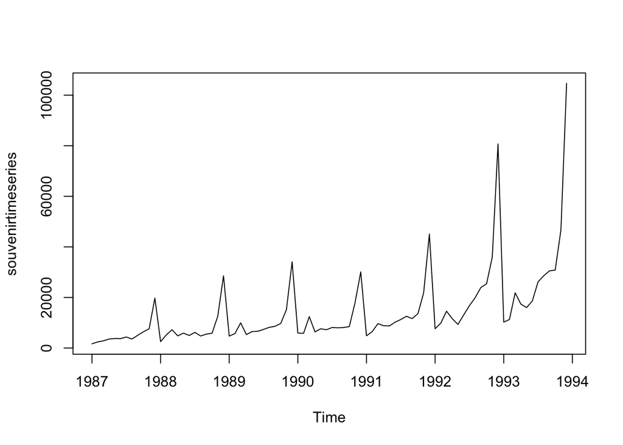

```r
library(TTR)
library(reshape2)
library(ggplot2)

# get a couple of time series, convert them to timeseries objects using ts() and plot them
souvenir <- scan("fancy.dat", sep="")
souvenirtimeseries <- ts(souvenir, frequency=12, start=c(1987,1))
plot.ts(souvenirtimeseries)
```

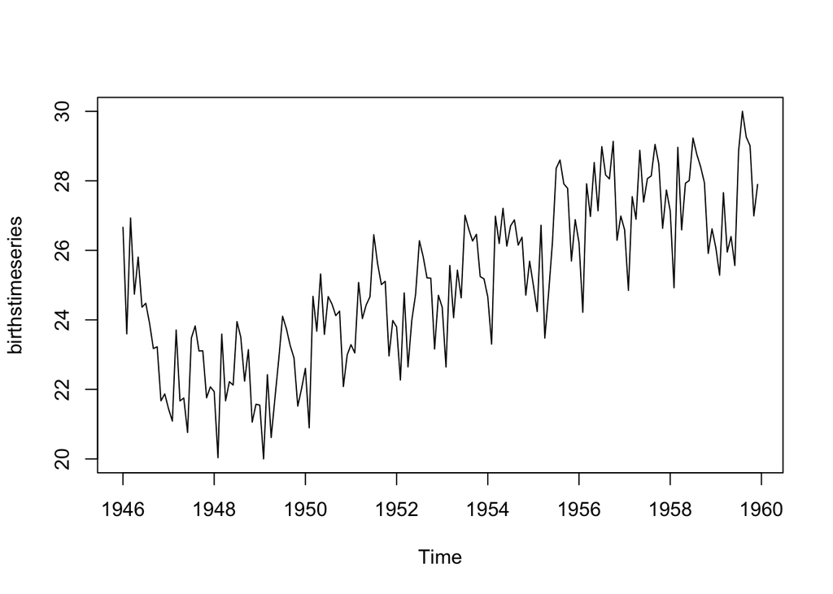

```r
births <- scan("nybirths.dat", sep="")
birthstimeseries <- ts(births, frequency=12, start=c(1946,1))
plot.ts(birthstimeseries)
```

#### Dekomposition von Zeitreihen

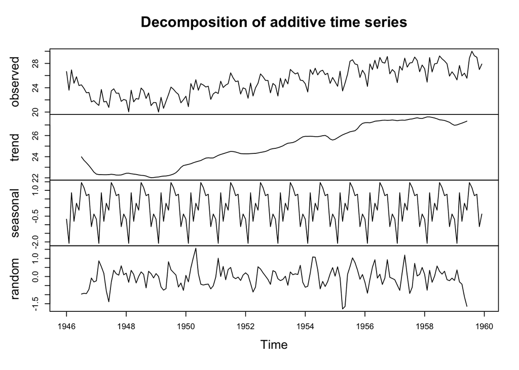

```r
# decompose time series into trend, seasonal and random component
# check data for additive/multiplicative model
birthstimeseriescomponents <- decompose(birthstimeseries, type="additive")
plot(birthstimeseriescomponents)
```

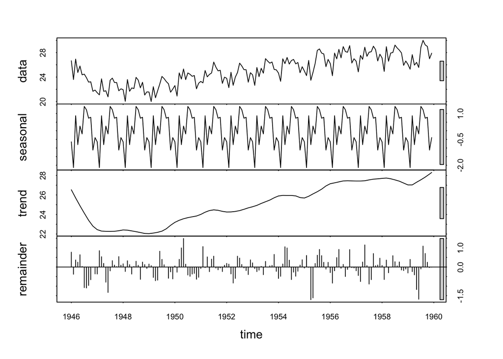

```r
# same with LOESS method
birthstimeseriescomponentsSTL <- stl(birthstimeseries, s.window="periodic")
plot(birthstimeseriescomponentsSTL)
```

#### Glättung zur Trendberechnung

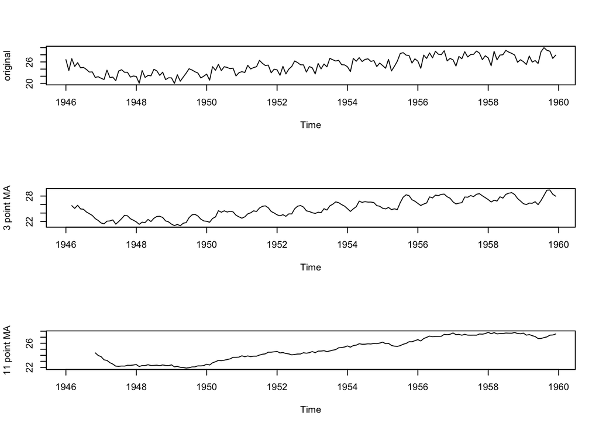

```r
#=============================================================
# smoothing

par(mfrow=c(3,1))
plot.ts(birthstimeseries, ylab="original")

# moving average over 3 points
birthstimeseriesSMA3 <- SMA(birthstimeseries,n=3)
plot.ts(birthstimeseriesSMA3, ylab="3 point MA")

# moving average over 11 points
birthstimeseriesSMA11 <- SMA(birthstimeseries,n=11)
plot.ts(birthstimeseriesSMA11, ylab="11 point MA")
```

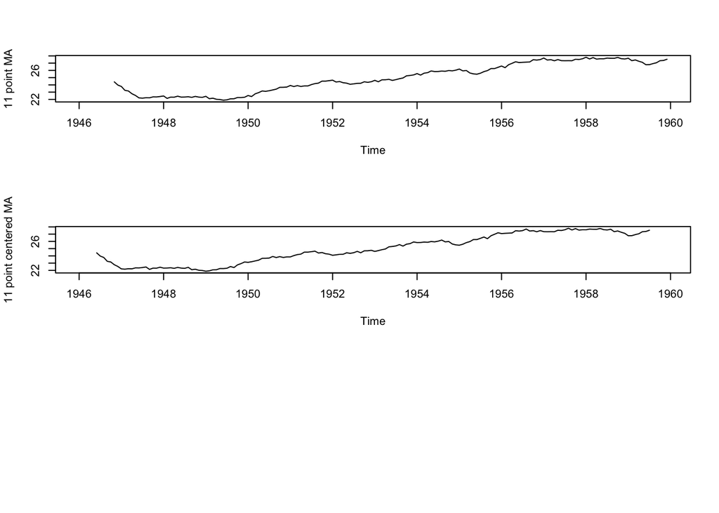

```r
# basic plot
plot.ts(birthstimeseriesSMA11, ylab="11 point MA")

# use filter() as alternative for SMA
birthstimeseries_filter11_centered <- stats::filter(birthstimeseries, rep(1/11, 11), sides=2)
plot.ts(birthstimeseries_filter11_centered, ylab="11 point centered MA")
```

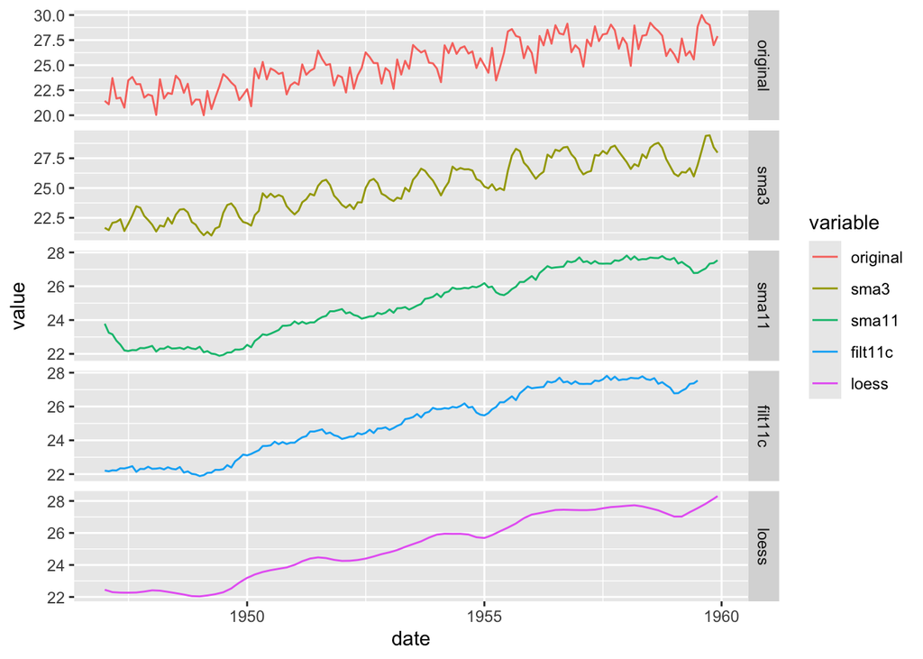

```r
# nicer plot using ggplot2
# convert the dates from the timeseries object into vector
new.date <- seq(as.Date(paste(c(start(birthstimeseries),1), collapse = "/")), by = "month", length.out  = length(birthstimeseries))

# form a data frame with the four timeseries including the LOESS trend
dat <- data.frame(date=new.date[13:length(birthstimeseries)], original=birthstimeseries[13:length(birthstimeseries)],
                  sma3 = birthstimeseriesSMA3[13:length(birthstimeseries)],
                  sma11 = birthstimeseriesSMA11[13:length(birthstimeseries)],
                  filt11c = birthstimeseries_filter11_centered[13:length(birthstimeseries)],
                  loess = birthstimeseriescomponentsSTL$time.series[13:length(birthstimeseries),"trend"]);

# reshape data for ggplot
dt.df <- melt(dat, measure.vars = c("original", "sma3", "sma11", "filt11c", "loess"))

# plot it
ggplot(dt.df, aes(x = date, y = value)) +
  geom_line(aes(color = variable)) +
  facet_grid(variable ~ ., scales = "free_y");
```

#### Additives versus Multiplikatives Modell

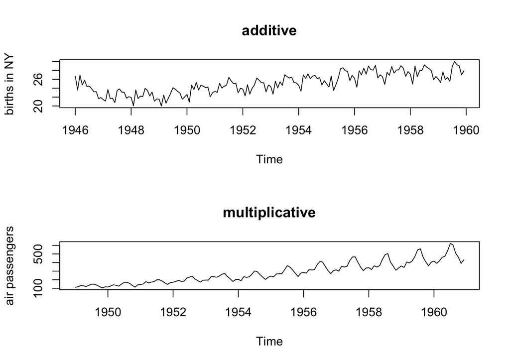

```r
#=============================================================
# compare two time series, one with additive decomposition, the other one [probably] multiplicative
library(Ecdat)
data(AirPassengers)
timeserie_air = AirPassengers
#plot(as.ts(timeserie_air))

par(mfrow=c(2,1))
plot.ts(birthstimeseries, main="additive", ylab = "births in NY")
#plot.ts(souvenirtimeseries, main="not additive")
plot(as.ts(timeserie_air), main="multiplicative", ylab = "air passengers")
```

#### Logarithmische Skalierung

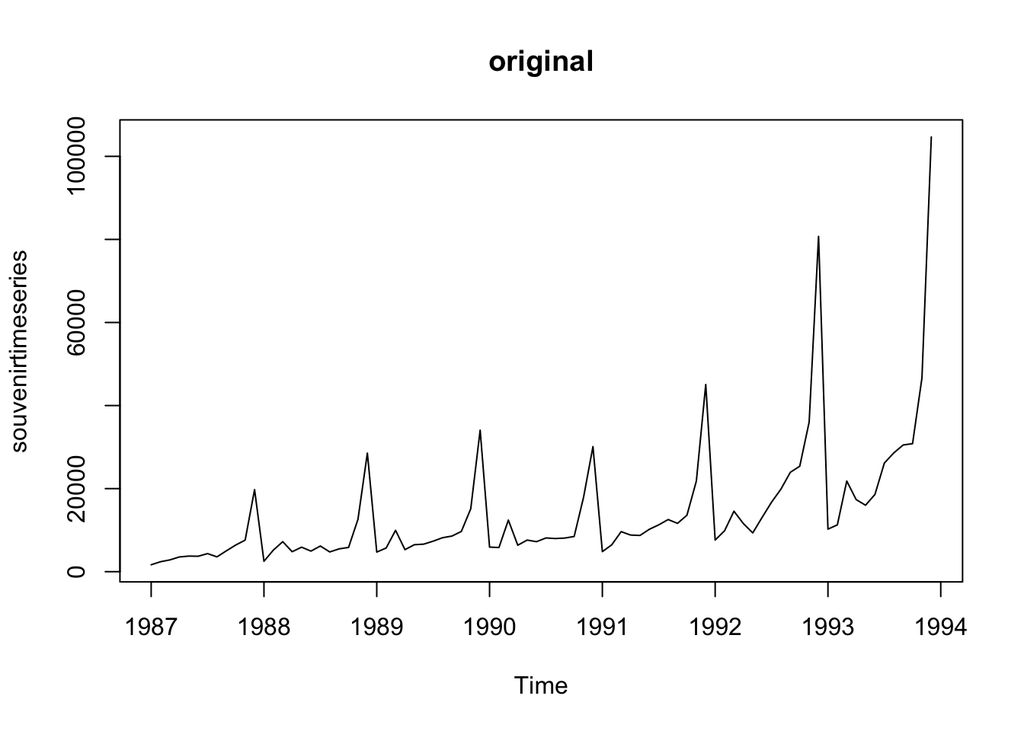

```r
# log scaling of a time series
logsouvenirtimeseries <- log(souvenirtimeseries)
plot.ts(souvenirtimeseries, main="original")
```

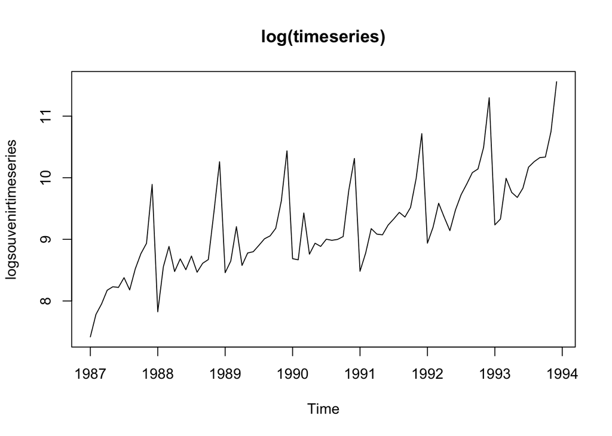

```r
plot.ts(logsouvenirtimeseries, main="log(timeseries)")
```

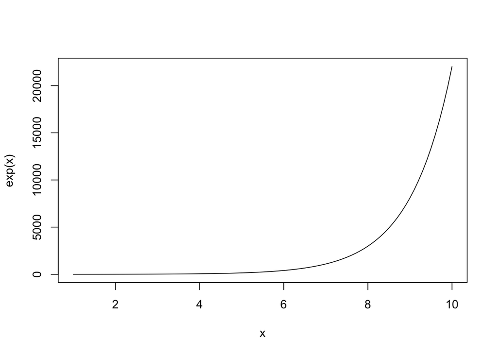

```r
par(mfrow=c(1,1))


# demonstrate log scaling on a basic exponential function
x <- seq(1,10,.1)
plot(x, exp(x), type = "l")
```

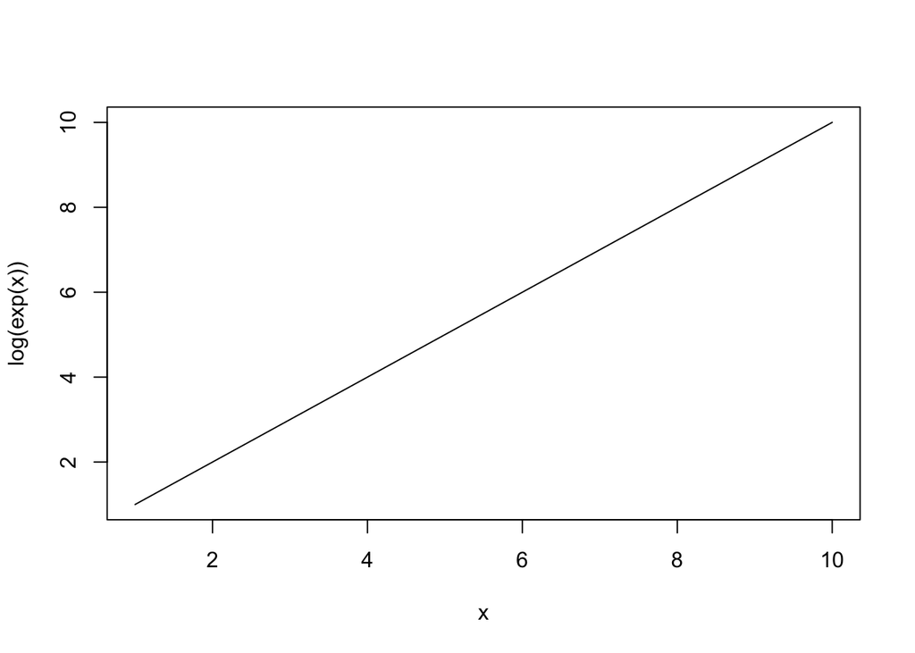

```r
plot(x, log(exp(x)), type = "l")
```

#### Auto-Korrelation

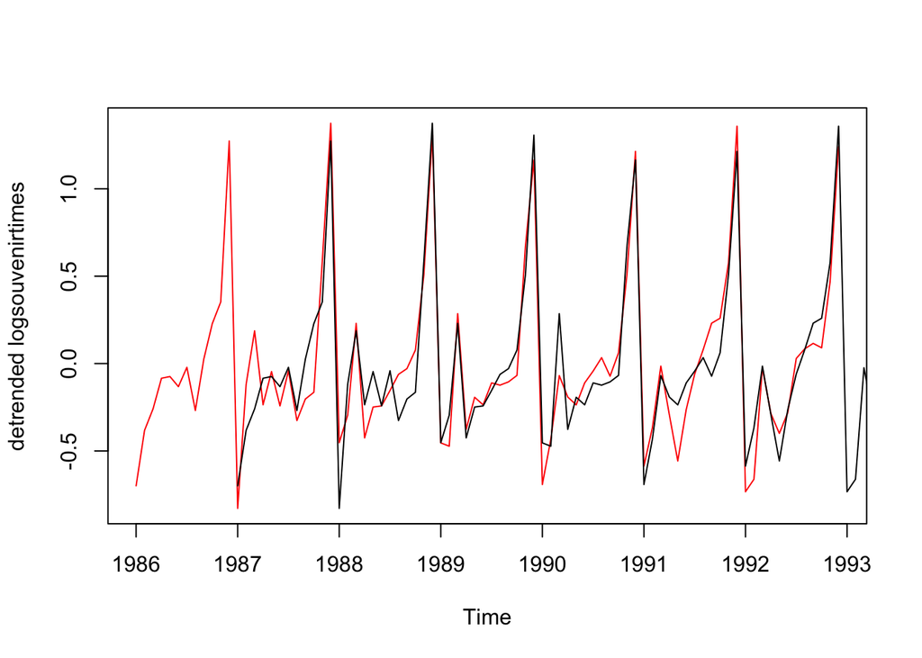

```r
# correlation of time series
decomp_logsouvenir <- stl(logsouvenirtimeseries, s.window="periodic")
detrended_logsouvenir <- logsouvenirtimeseries - decomp_logsouvenir$time.series[,"trend"]

# produce shifted version (by 12 months) of the detrended souvenir time series
shift_ts <- lag(detrended_logsouvenir, 12)

# plot both
plot(shift_ts, main="", ylab="detrended logsouvenirtimes", col="red")
lines(detrended_logsouvenir)
```

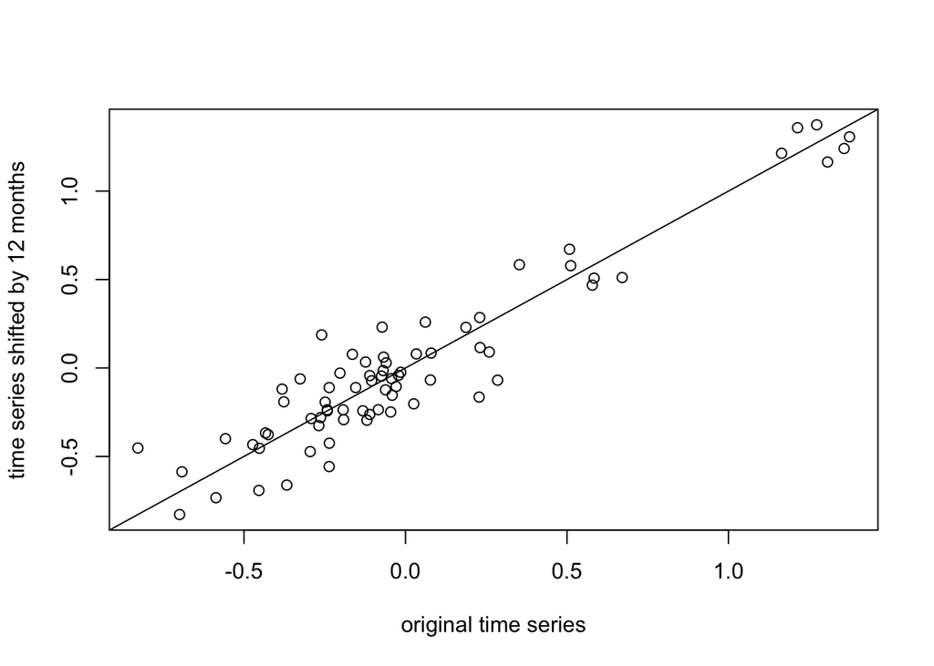

```r
# plot against another as scatter plot
n <- length(detrended_logsouvenir)
plot(as.numeric(detrended_logsouvenir[1:(n-12)]), as.numeric(detrended_logsouvenir[13:n]),
     xlab="original time series", ylab="time series shifted by 12 months")
abline(0,1)
```

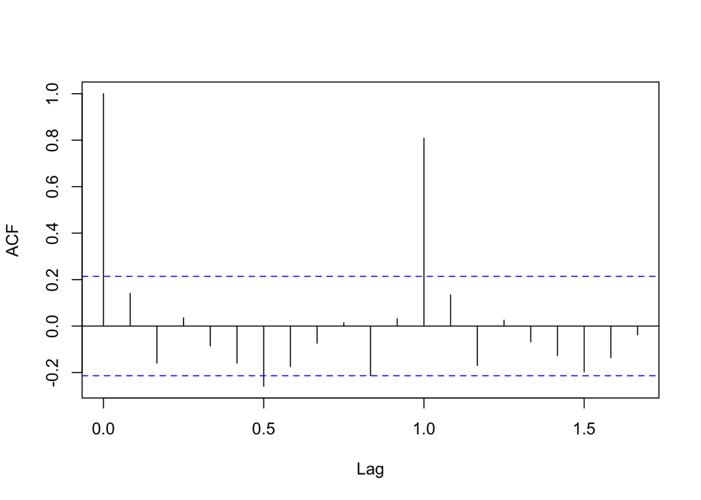

```r
# look at auto-correlation in the detrended timeseries,
# i.e. correlation with a time-shifted versions of itself
a <- acf(detrended_logsouvenir, lag.max=20, main="")
```

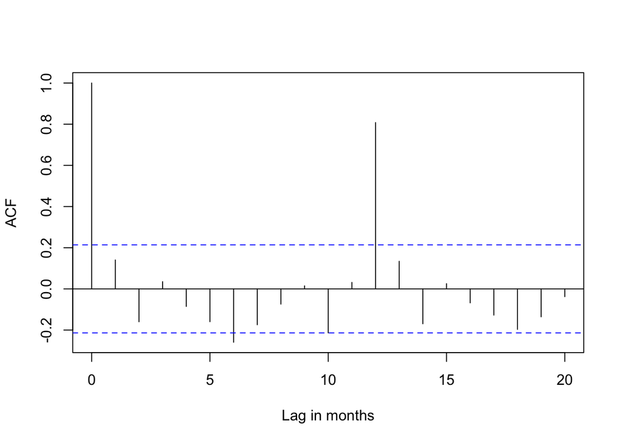

```r
a$lag <- a$lag * 12 # scale lag up to months for comprehensibility
plot(a, xlab = "Lag in months", main = "")
```

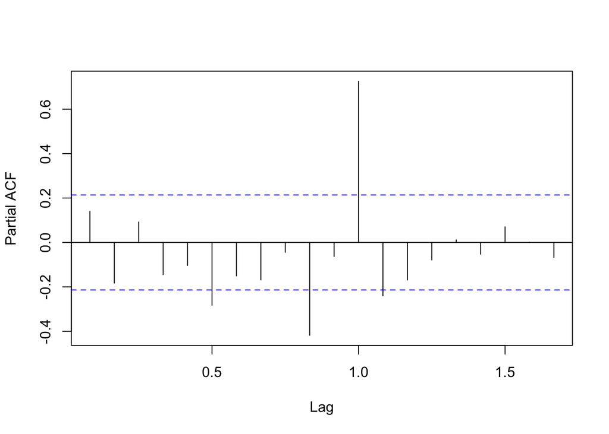

```r
# and partial auto-correlation
pa <- pacf(detrended_logsouvenir, lag.max=20, main="")
```

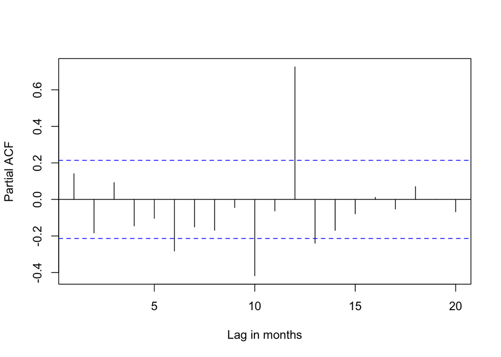

```r
pa$lag <- pa$lag * 12 # scale lag up to months for comprehensibility
plot(pa, xlab = "Lag in months", main = "")
```

#### Zeitreihen berichten

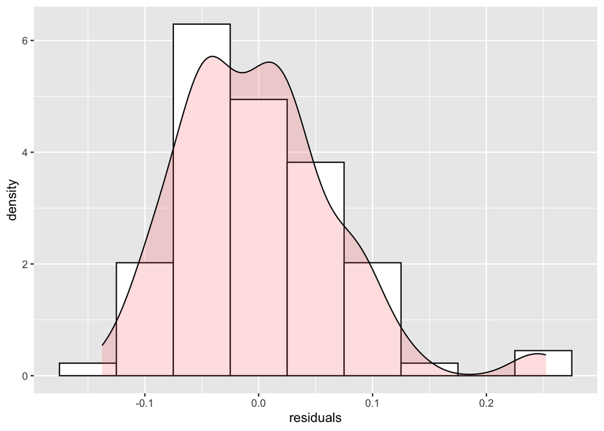

```r
# read the data
fault_rate_data <- read.table("fault_rates.csv", sep=",", header = TRUE)

# add an index for the date
fault_rate_data[,"date_index"] <- as.numeric(rownames(fault_rate_data))

# smoothing span is ratio of smoothing window size
# and the overall number of time steps (points)
smoothing_span <- 30/nrow(fault_rate_data)

# smooth the time series using loess
fault_rate_smoothed <- loess(fault_rate ~ date_index, fault_rate_data, span=smoothing_span);

# compute the standard deviation of the residuals, i.e. the error of the smoothed curve
std_dev <- sd(fault_rate_smoothed$residuals)

# threshold in number of standard deviations for upper and lower control limit
threshold <- 2


# compute the lower and upper control level curves
lcl <- fault_rate_smoothed$fitted - threshold * std_dev
ucl <- fault_rate_smoothed$fitted + threshold * std_dev

# add vectors to data frame
fault_rate_data$residuals <- fault_rate_smoothed$residuals
fault_rate_data$lcl <- lcl
fault_rate_data$ucl <- ucl
fault_rate_data$loess <- fault_rate_smoothed$fitted
fault_rate_data$outlier <- abs(fault_rate_smoothed$residuals) / std_dev > threshold

# histogram
ggplot(fault_rate_data, aes(x=residuals)) +
  geom_histogram(aes(y=..density..),      # Histogram with density instead of count on y-axis
                 binwidth=.05,
                 colour="black", fill="white") +
  geom_density(alpha=.2, fill="#FF6666")  # Overlay with transparent density plot
```

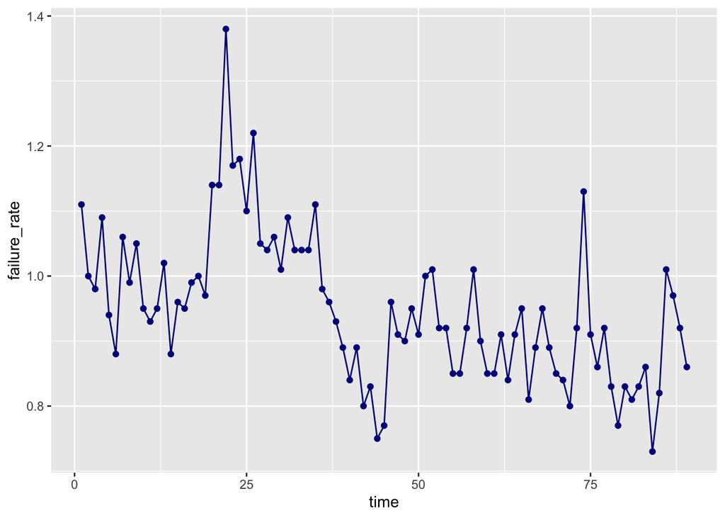

```r
# plot the time series
ggplot(aes(x=date_index, y=fault_rate), data=fault_rate_data) +
  geom_line(colour="darkblue") +
  geom_point(colour="darkblue") +
  xlab("time") + ylab("failure_rate")
```

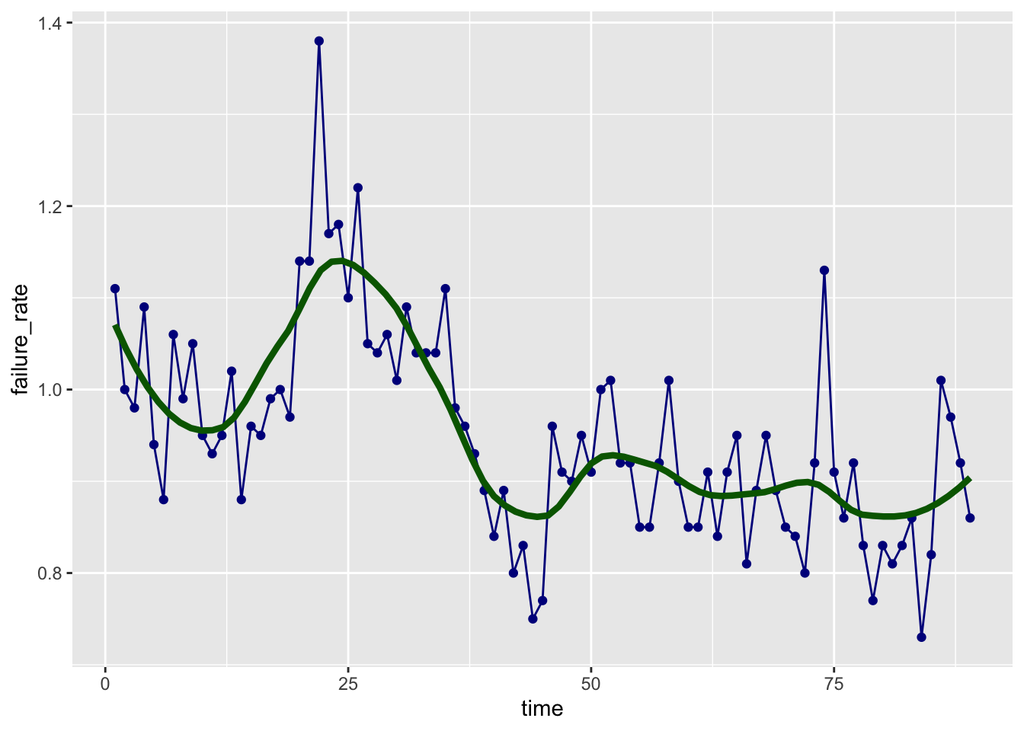

```r
# add smoothed curve
ggplot(aes(x=date_index, y=fault_rate), data=fault_rate_data) +
  geom_line(colour="darkblue") +
  geom_point(colour="darkblue") +
  geom_smooth(method="loess", colour="darkgreen", size=1.5, span=smoothing_span, level=0) +
  xlab("time") + ylab("failure_rate")
```

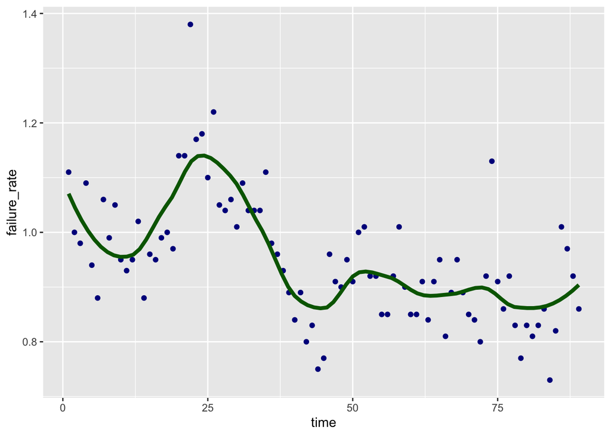

```r
# add smoothed curve, stick to points only for data
ggplot(aes(x=date_index, y=fault_rate), data=fault_rate_data) +
  geom_point(colour="darkblue") +
  geom_smooth(method="loess", colour="darkgreen", size=1.5, span=smoothing_span, level=0) +
  xlab("time") + ylab("failure_rate")
```

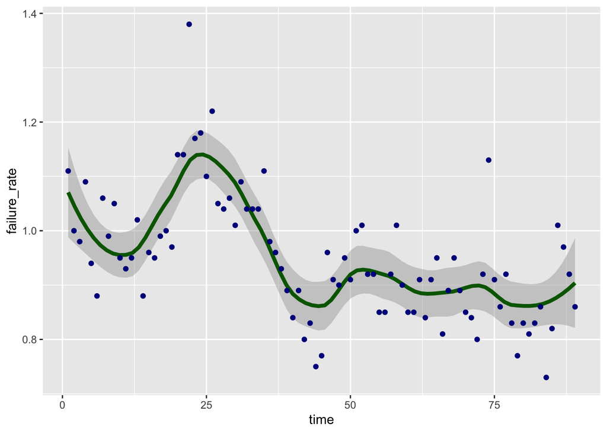

```r
# add smoothed curve, stick to points only for data
ggplot(aes(x=date_index, y=fault_rate), data=fault_rate_data) +
  geom_smooth(method="loess", colour="darkgreen", size=1.5, span=smoothing_span, level=0.95) +
  geom_point(colour="darkblue") +
  xlab("time") + ylab("failure_rate")
```

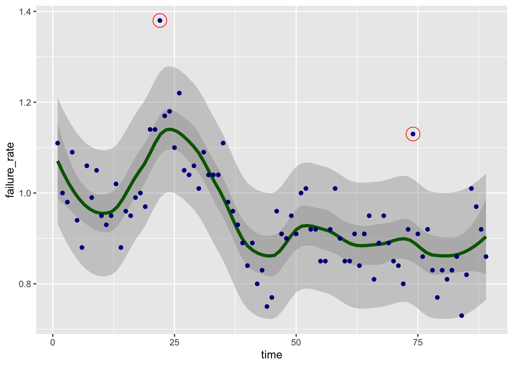

```r
# add confidence interval of data around smoothed curve
ggplot(aes(x=date_index, y=fault_rate), data=fault_rate_data) +
  scale_colour_manual(values=c("TRUE"="red","FALSE"="blue")) +
  geom_point(shape=1, aes(colour=outlier, size=as.numeric(outlier))) +
  geom_smooth(aes(ymin = lcl, ymax = ucl), stat="identity", size=0) +
  geom_smooth(method="loess", colour="darkgreen", size=1.5, span=smoothing_span, level=0.95) +
  geom_point(colour="darkblue") +
  xlab("time") + ylab("failure_rate") +
  theme(legend.position="none")
```